# report1

Kierra Zhu

6/21/2022

# Introduction

This project will using dataset providing by California Teachers Study(CTS) with a preference on OSHPD Hospitalization records.

The main purpose of this project is to predict short-term death risk primarily recording to prior in-patient hospitalization, accompanied by basic personal information such as age, race, height, weight, physical activity and alcohol use.

And there are four specific aims that are: * develop the best fitting model to predict the probability of death within a certain time window * check if time window works after putting hospitalization characteristics into model * look up certain phenotypes of co-morbidities that influence the risk of death * find out temporal and spatial trends related to death

## check variables eligible or not

### import libraries

```r
combined_data<-read.csv('combinedata.csv')
library(dplyr)
library(ggplot2)
library(tidyverse)
```

### get out the unique patient and check if there’s empty rows

```r
uni_data<-distinct(combined_data,participant_key,.keep_all = TRUE)
uni_data<-
  uni_data%>%
  filter(!if_all( ,is.na))
```

```r
df1<-uni_data[, -which(colMeans(is.na(uni_data))>0.75)]
dim(df1)
```

```
## [1] 48324   138
```

### get df2 through cutting repeated variables like: src_admission_cde, facility_county_cde

```r
df2<-df1[,-c(82,90)]
```

### get df3 through getting rid of irrelevant variables like: study_start_date_q3, analysis_end_date

```r
df3<-df2[,-c(133,134)]
```

```r
sele_data<-df3
```

# data visualization

### check the ratio of deceaced people

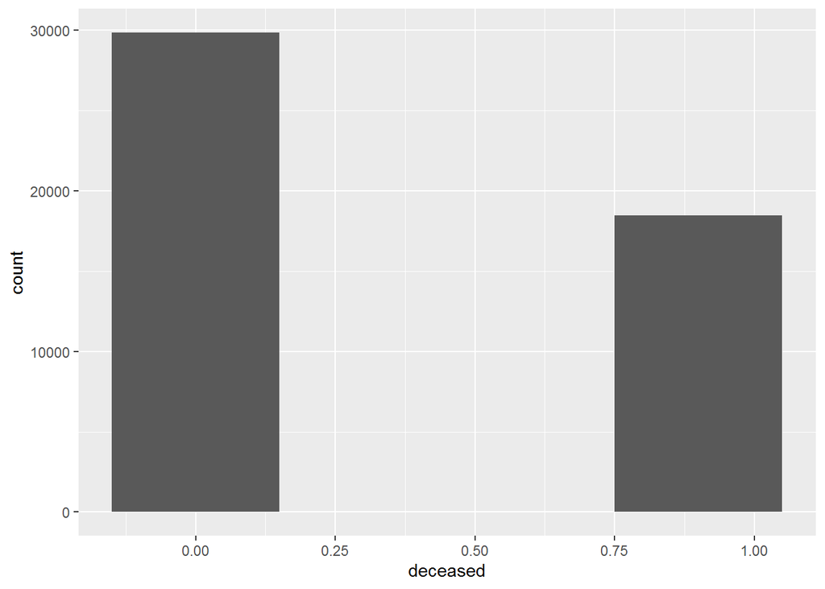

```r
  ggplot(sele_data,aes(x=deceased))+
  geom_histogram(binwidth = 0.3)+
  scale_fill_brewer(palette="Blues")
```

### check age, race and bmi data distribution

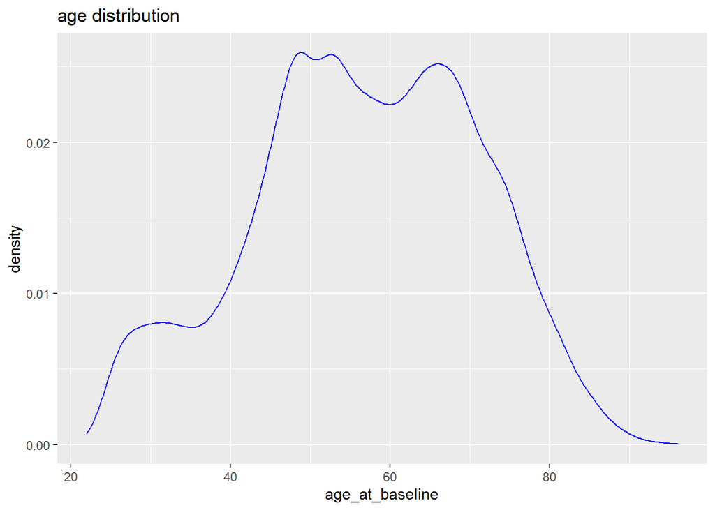

```r
# age
p_age<-
  ggplot(sele_data,aes(x=age_at_baseline))+
  geom_density(color='#0000FF')

p_age+labs(title='age distribution')
```

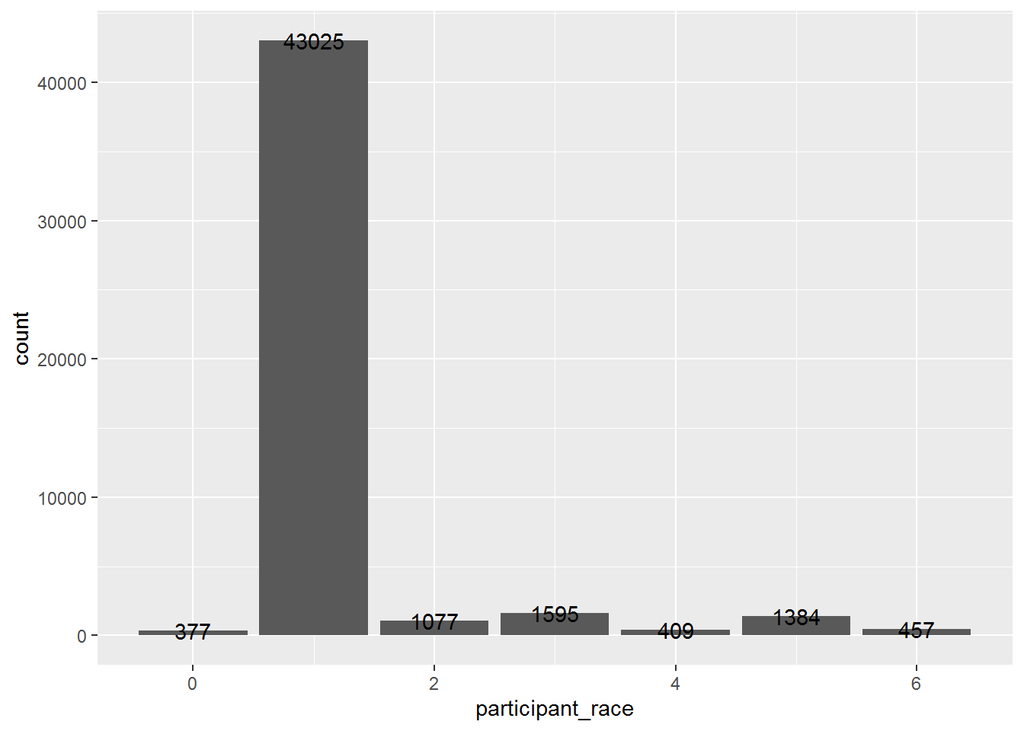

```r
#race
fl=c('None reported','White','Black','Hispanic','Native American','Asian or Pacific Islander','Other&Mixed')
p_race<- ggplot(sele_data,aes(x=participant_race))+
        geom_bar()+
        geom_text(aes(label=..count..),stat = "count")

p_race
```

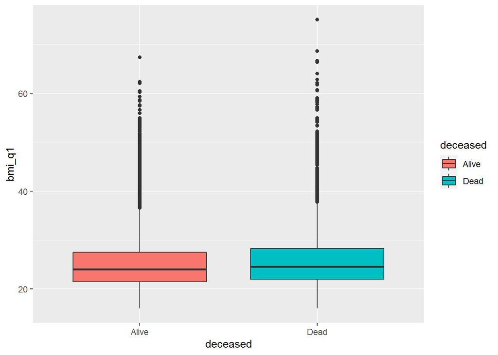

```r
#bmi
sele_data$deceased<-factor(sele_data$deceased,level=c(0,1),labels = c('Alive','Dead'))
p_bmi<-ggplot(sele_data,aes(y=bmi_q1,x=deceased,fill=deceased))+geom_boxplot()
p_bmi
```